# Determining the execution of fitness excercises from sensor data

# Preparation of the train test and validation dataframe

Since I want to do some cross validation I will split the data in 3 parts. I have taken the rule-of-thumb mentioned in the video to split the data. This means the data will be split in 60% training, 20% validation and 20% testing. I have echoed all R code, so if you would put all the code from this site in an R file it should run and produce the results I have.

The “assignmentTest” variable is for the machine-checked prediction results.

## Loading and splitting

```r
set.seed(30042)
alldata <- read.csv("pml-training.csv")
assignmentTest <- read.csv("pml-testing.csv")


library(caret)
inTrain <- createDataPartition( y = alldata$classe, p = 0.6, list = FALSE)
training <- alldata[inTrain,]
testingAndValidation <- alldata[-inTrain,]

inTrain <- createDataPartition( y = testingAndValidation$classe, p = 0.5, list = FALSE)
testing <- testingAndValidation[inTrain,]
validation <- testingAndValidation[-inTrain,]
```

## Cleaning redundant information and coercing to numerical data

I have found the standard deviation and variance of some of the signals from the sensors. However this information is ofcourse redundant so I have removed all standard deviation and variance data. The training dataframe has some variables which have class “factor” so these should be converted to numerical variables. If there is something else in the colum (text like “DIV/0”) it will put an “NA” which is nice since we then can find out how many real numerical datapoints we really have.

```r
training <-(training) [grep(".*var.*", names(training), perl = T, invert = T)]
training <-(training) [grep(".*stddev.*", names(training), perl = T, invert = T)]
training$X <- NULL

training$classe = as.numeric(training$classe)


factor2Num <- function(factorIn)
{
   dataChar = as.character(factorIn)
   dataNum = suppressWarnings(as.numeric(dataChar))
}

training = as.data.frame(apply(X = training, MARGIN = 2, FUN = factor2Num ))
```

## Making some plots to explore the data

I will plot the data to find out what kind of machine learning model would be appropriate. First I plot the result of the same sensor which measures in 2 directions, after that I plot the results of different sensors. The pairs plot compares all different sensors.

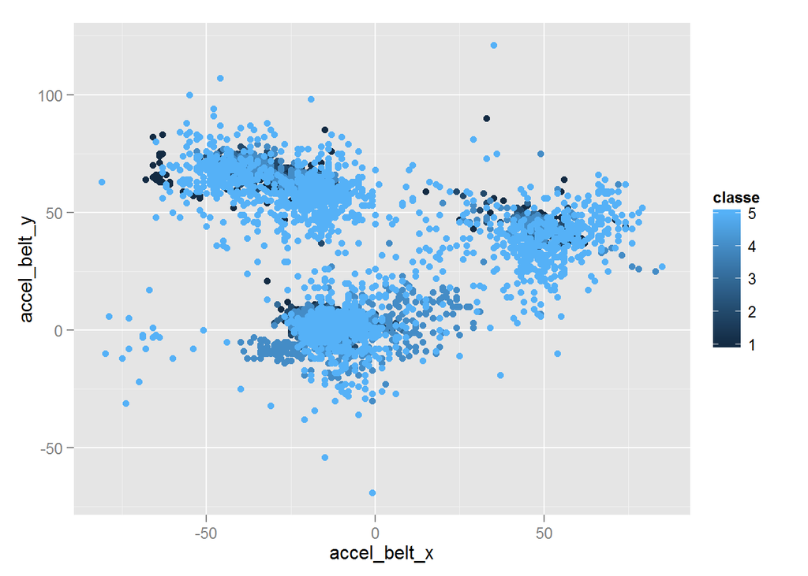

```r
qplot(accel_belt_x, accel_belt_y , data=training, colour = classe)
```

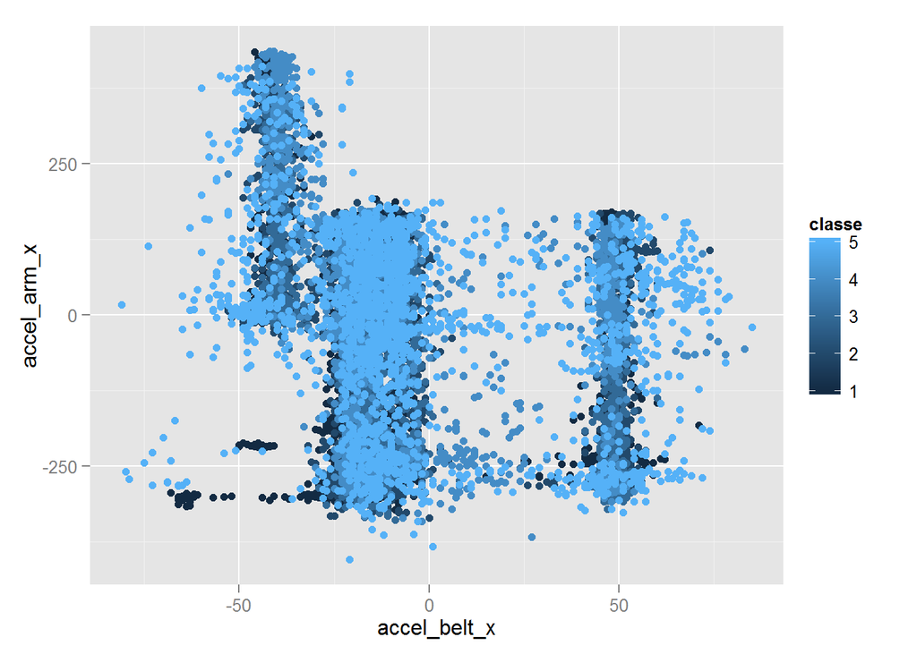

```r
qplot(accel_belt_x, accel_arm_x , data=training, colour = classe)
```

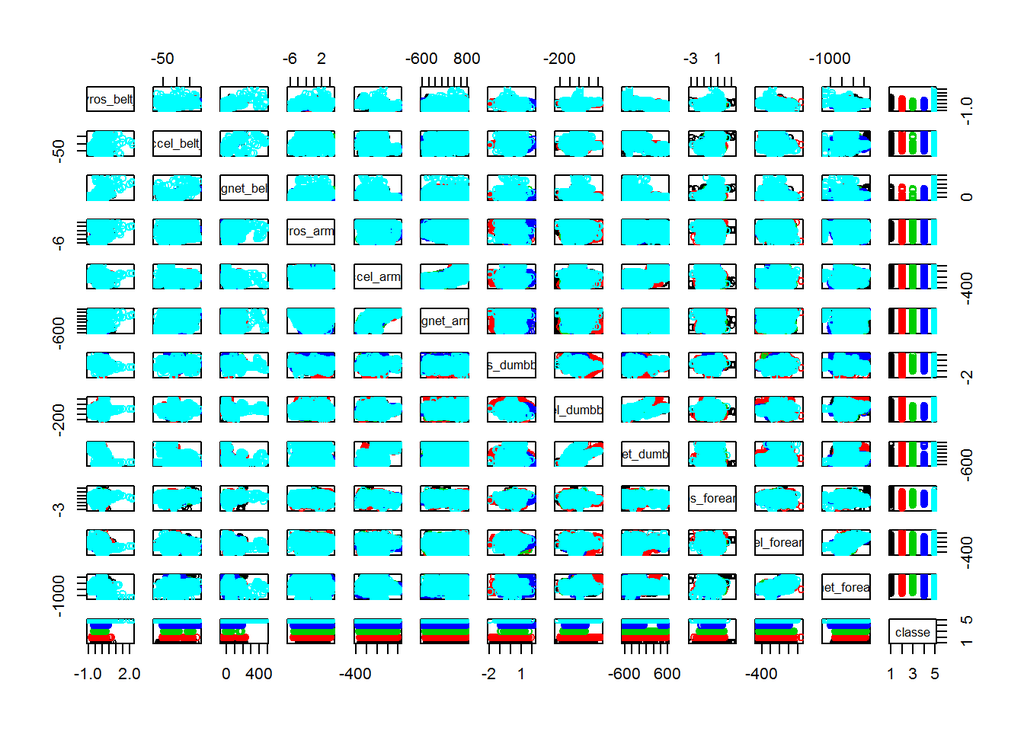

```r
trainIndexForPlot = grep('.*_x$', names(training))
trainPlotSub = training[,trainIndexForPlot]
trainPlotSub$classe <- training$classe
pairs(trainPlotSub, col = trainPlotSub$classe)
```

I would say the pairs plot shows random forest is a good choice. As you can see it also suggests the boosting method.

## Cleaning the NA values

I have manually looked at the variables and I found some variables have a very big amount of ‘NA’ values. Also the fraction of NA’s for these are exactly the same, and if I take out these columns from the dataframe the remaining columns have no NA’s at all.

Note I change the “classe” value to a factor. It has been coerced to a number before so now the levels of my classe are not {A,B,C,D,E} but {1,2,3,4,5}.

```r
colName = names(training)
aa <- logical(length(colName))
for (colIndex in 1:(length(colName)-1))
{

   fraction = sum( is.na( training[,colIndex])) / length(training[,colIndex])
   if(fraction > 0.9)
   {
      aa[colIndex] = T
   }
   else
   {
      aa[colIndex] = F
   }

}

training = training[,!aa]

training$classe = as.factor(training$classe)
```

I have tried to use “glm”, “boosting” and “rt”. “gml” Was the least suitable and the “rt” seems to be the best. This is done only with the validation variable and because the partition function of caret chooses random number from the “train” dataframe to be placed in the “validation” frame this is the simplest form of *cross validation*.

I *expect my out-of-sample error* to be exactly the same as the results one can find in the confusion matrix of the validation matrix.

```r
modelFit = train(classe~., data = training, method = "rf")
predictions <- predict(modelFit, newdata=validation)

# This shows the validation result with which I made the model to optimize "accuracy"
print(confusionMatrix(predictions, as.factor(as.numeric(validation$classe))))
```

```
## Confusion Matrix and Statistics
##
##           Reference
## Prediction    1    2    3    4    5
##          1 1116    0    0    0    0
##          2    0  759    0    0    0
##          3    0    0  684    1    0
##          4    0    0    0  642    0
##          5    0    0    0    0  721
##
## Overall Statistics
##
##                Accuracy : 0.9997
##                  95% CI : (0.9986, 1)
##     No Information Rate : 0.2845
##     P-Value [Acc > NIR] : < 2.2e-16
##
##                   Kappa : 0.9997
##  Mcnemar's Test P-Value : NA
##
## Statistics by Class:
##
##                      Class: 1 Class: 2 Class: 3 Class: 4 Class: 5
## Sensitivity            1.0000   1.0000   1.0000   0.9984   1.0000
## Specificity            1.0000   1.0000   0.9997   1.0000   1.0000
## Pos Pred Value         1.0000   1.0000   0.9985   1.0000   1.0000
## Neg Pred Value         1.0000   1.0000   1.0000   0.9997   1.0000
## Prevalence             0.2845   0.1935   0.1744   0.1639   0.1838
## Detection Rate         0.2845   0.1935   0.1744   0.1637   0.1838
## Detection Prevalence   0.2845   0.1935   0.1746   0.1637   0.1838
## Balanced Accuracy      1.0000   1.0000   0.9998   0.9992   1.0000
```

I have here the confusionmatrix for the *testing* set, so this is a set I have not used in the project to build to model.

```r
finalPredictions <- predict(modelFit, newdata=testing)
print(confusionMatrix(finalPredictions, as.factor(as.numeric(testing$classe))))
```

```
## Confusion Matrix and Statistics
##
##           Reference
## Prediction    1    2    3    4    5
##          1 1116    0    0    0    0
##          2    0  759    3    0    0
##          3    0    0  681    2    0
##          4    0    0    0  641    1
##          5    0    0    0    0  720
##
## Overall Statistics
##
##                Accuracy : 0.9985
##                  95% CI : (0.9967, 0.9994)
##     No Information Rate : 0.2845
##     P-Value [Acc > NIR] : < 2.2e-16
##
##                   Kappa : 0.9981
##  Mcnemar's Test P-Value : NA
##
## Statistics by Class:
##
##                      Class: 1 Class: 2 Class: 3 Class: 4 Class: 5
## Sensitivity            1.0000   1.0000   0.9956   0.9969   0.9986
## Specificity            1.0000   0.9991   0.9994   0.9997   1.0000
## Pos Pred Value         1.0000   0.9961   0.9971   0.9984   1.0000
## Neg Pred Value         1.0000   1.0000   0.9991   0.9994   0.9997
## Prevalence             0.2845   0.1935   0.1744   0.1639   0.1838
## Detection Rate         0.2845   0.1935   0.1736   0.1634   0.1835
## Detection Prevalence   0.2845   0.1942   0.1741   0.1637   0.1835
## Balanced Accuracy      1.0000   0.9995   0.9975   0.9983   0.9993
```